# Archivos, formatos y rutas

Introducción a la Ciencia de Datos — Universidad de Montevideo

## Lo que vimos hasta ahora en el curso

|  | Tema | Qué hicimos |
| --- | --- | --- |
| 📋 | Medición y encuestas | operacionalización, niveles de medición, diseño de un cuestionario |
| 📂 | Carga de datos | leer archivos en distintos formatos; rutas y directorio de trabajo |
| 🔎 | Perfilado y fechas | filas, columnas, faltantes, fechas y agregación con los datos abiertos de aire y tránsito |
| 📊 | Gráficos | las partes de un gráfico, más de una serie, colores por grupo |
| 🔗 | Unión de tablas | merge de ozono con PM2.5 por la hora |
| ⏱️ | Series de tiempo | grilla regular, rezago y autocorrelación |
| 🧾 | IA y OCR | leer tickets: la imagen se manda como bytes a la API de Gemini |
| 📈 | Variables y modelo | variables nuevas, correlación y la recta, con la tabla de tránsito y aire |

Hoy volvemos a la base: **qué hay dentro de un archivo, y cómo lo encuentra el programa.**

# Qué es un archivo

## El bit y el byte 💡

**Bit** (*binary digit*). La unidad mínima de información: vale 0 o 1. En el hardware es algo que está en uno de dos estados, como un interruptor apagado o encendido.

**Byte.** Un grupo de 8 bits. Con 8 lugares que valen 0 o 1 hay 2<sup>8</sup> = 256 combinaciones distintas: de `00000000` a `11111111`, es decir, de 0 a 255.

Cada lugar vale el doble que el de su derecha, como en el sistema decimal cada lugar vale diez veces más:

| Valor del lugar | 128 | 64 | 32 | 16 | 8 | 4 | 2 | 1 |
| --- | --- | --- | --- | --- | --- | --- | --- | --- |
| Bits | 0 | 1 | 0 | 0 | 0 | 0 | 0 | 1 |

`01000001` = 64 + 1 = **65**. En la tabla ASCII, 65 es la letra **A**. 🅰️

## El hexadecimal: un byte en dos cifras

Escribir `01000001` es largo. El **sistema hexadecimal** usa 16 cifras: `0 1 2 3 4 5 6 7 8 9 A B C D E F`, donde A vale 10 y F vale 15.

Cada cifra hexadecimal reemplaza exactamente 4 bits, así que un byte siempre se escribe con dos cifras:

| Bits | Se parte en | Hexadecimal | Decimal |
| --- | --- | --- | --- |
| `01000001` | `0100` · `0001` | `41` | 65 |
| `11000011` | `1100` · `0011` | `C3` | 195 |
| `11111111` | `1111` · `1111` | `FF` | 255 |

Por eso en esta clase los bytes aparecen como `41`, `C3` o `FF`. En Python, un byte que no es un carácter se muestra como `\xc3`: la `\x` avisa que lo que sigue es hexadecimal.

## Cuánto ocupa un archivo 📏

| Unidad | Bytes | Un ejemplo del curso |
| --- | --- | --- |
| byte | 1 | una letra sin tilde en un CSV |
| kilobyte (KB) | 1000 | `ventas.csv`: 70 bytes; `transito_aire_junio2024.csv`: 131 KB |
| megabyte (MB) | 1 000 000 | una foto de 1000 × 1000 píxeles sin comprimir: 3 MB |
| gigabyte (GB) | 1 000 000 000 | una película, o un año de datos minutales de varias estaciones |

Windows cuenta de a 1024 en lugar de 1000 (1 KB = 1024 bytes), así que los tamaños que muestra pueden diferir un poco de estos.

## Un archivo es una secuencia de bytes con un nombre

**Archivo.** Secuencia finita de bytes guardada en un disco, con un nombre y una ubicación (la carpeta donde está). El archivo no sabe qué significan sus bytes: eso lo decide el programa que lo lee.

Los primeros 12 bytes de `ventas.csv`:

66

65

63

68

61

2C

6C

6F

63

61

6C

2C

Así lo ve la computadora: solo números. 🤖 Para saber si son letras, píxeles o celdas de una planilla, hace falta una regla que diga cómo leerlos.

## Todo archivo es una fila de bytes: cambia la regla para leerlos

|  | Archivo | Primeros bytes | Qué son |
| --- | --- | --- | --- |
| 📄 | `ventas.csv` | `66 65 63 68 61 2C` | las letras «fecha,» |
| 🐍 | `saludo.py` | `70 72 69 6E 74 28` | las letras «print(» |
| 📊 | `ventas.xlsx` | `50 4B 03 04` | «PK»: la firma de un archivo ZIP |
| 📕 | `ejercicios.pdf` | `25 50 44 46` | «%PDF»: la firma de un PDF |
| 🖼️ | `foto.jpg` | `FF D8 FF E0` | la firma de una imagen JPG |
| 🔊 | `tono.wav` | `52 49 46 46` | «RIFF»: la firma de un audio WAV |

Los primeros bytes de muchos formatos son una **firma**: le dicen al programa qué tipo de archivo es. Después vienen letras, píxeles, celdas o sonido, según el formato.

## Texto plano: cada byte es un carácter

**Archivo de texto plano.** Archivo cuyos bytes representan solo caracteres, según una codificación (una tabla que asigna un número a cada carácter). No guarda formato: ni negrita, ni colores, ni imágenes.

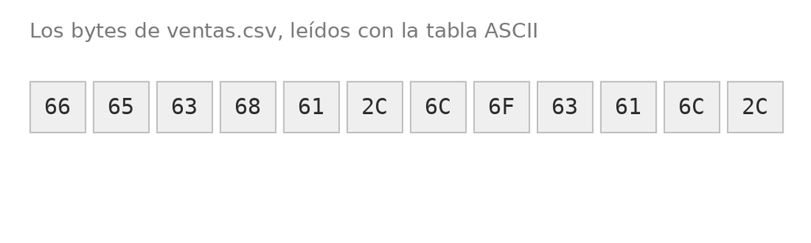

Son de texto plano: `.txt` `.csv` `.py` `.R` `.qmd` `.md` `.json` `.html`. Se pueden abrir y leer con cualquier editor de texto.

## Archivo binario: los bytes no son caracteres

**Archivo binario.** Archivo cuyos bytes siguen una estructura propia del formato: números, imágenes comprimidas, partes de otros archivos. Solo lo lee bien el programa que conoce esa estructura.

`ventas.xlsx` abierto con el Bloc de notas: 🗑️

```
PK   ? a]I:O  [Content_Types].xmlËnÂ0 E÷ý
ÈÛ*1tQUEË©ô\{B,ÛòþŸðP[Q M¬dîÜsÇ<--
```

Un `.xlsx` es una carpeta de archivos comprimida (por eso empieza con PK, como un ZIP). El resto no son caracteres, y el editor los muestra como basura.

Los mismos datos, 3 columnas y 2 filas:

70 bytes en `ventas.csv`

5360 bytes en `ventas.xlsx`

## Texto o binario: cómo se guarda el número 1250,5

**En un archivo de texto** se guardan los caracteres que se ven: «1», «2», «5», «0», «.», «5». Son 6 bytes, uno por carácter:

131

232

535

030

.2E

535

**En un archivo binario** se guarda el número mismo, con la regla que usa la computadora para hacer cuentas: un número decimal ocupa siempre 8 bytes.

@40

“93

Š8A

00

00

00

00

00

Arriba de cada byte: lo que muestra el Bloc de notas si lo lee como texto. 🗑️

- En texto, al leer, el programa tiene que **traducir caracteres a números**. Ahí aparecen los problemas de separador, decimal y codificación.
- En binario el número ya está listo, pero hay que **saber el formato**: dónde empieza cada dato y cuántos bytes ocupa.

## Un ejemplo de R: el formato .rds 📦

```r
ventas <- read.csv("ventas.csv")
saveRDS(ventas, "ventas.rds")
ventas2 <- readRDS("ventas.rds")
identical(ventas, ventas2)   # TRUE
```

`ventas.rds` empieza con `1F 8B`: la firma de un archivo comprimido con gzip. 🗜️

Sin comprimir (`compress = FALSE`), adentro está la columna `monto`:

| vector de números decimales (tipo 14) | 00 00 00 0E |
| --- | --- |
| con 2 valores | 00 00 00 02 |
| 1250,5 | 40 93 8A 00 00 00 00 00 |
| 980 | 40 8E A0 00 00 00 00 00 |

**Gana:** se lee de nuevo idéntica, con los tipos de cada columna, sin separador ni decimal. **Pierde:** solo la lee R (Python necesita un paquete como `pyreadr`), no se puede abrir con el Bloc de notas y Git no muestra qué cambió.

## Una imagen también es una secuencia de bytes

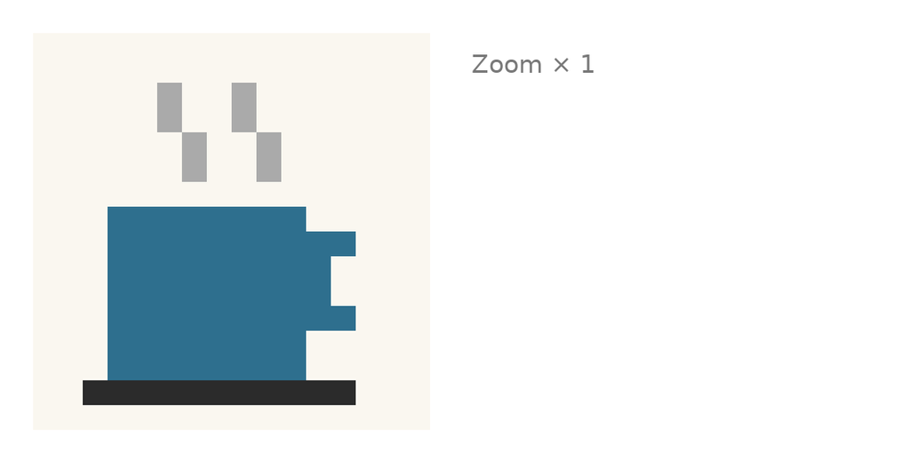

**Píxel.** Cada punto de una imagen. Su color se guarda con tres bytes: cuánto rojo, cuánto verde y cuánto azul tiene, de `00` a `FF`.

Un JPG comprime los píxeles: abierto con el Bloc de notas, es basura.

En la clase de OCR, la foto del ticket se abrió así: 🧾

```python
archivo = open(RUTA + FOTO, "rb")
```

`"rb"`: *read binary*, leer los bytes sin tratarlos como texto.

## Texto plano y binario, lado a lado

|  | Texto plano 📄 | Binario 📦 |
| --- | --- | --- |
| Qué guardan los bytes | Caracteres, según una codificación | Una estructura propia del formato |
| Para leerlo hace falta | Saber la codificación | Un programa que conozca el formato |
| Con el Bloc de notas | Se lee y se puede editar | Se ve basura; si se guarda, se rompe |
| En Git (GitHub Desktop) | Muestra qué líneas cambiaron | Solo dice que el archivo cambió |
| En Python | `open(ruta, "r", encoding="utf-8")` | `open(ruta, "rb")` |
| Ejemplos | `.txt` `.csv` `.py` `.R` `.qmd` `.json` | `.xlsx` `.docx` `.pdf` `.jpg` `.zip` |

**Criterio:** un archivo es de texto plano si, leídos sus bytes con una codificación, todo lo que aparece son caracteres y el texto tiene sentido.

## Actividad: seis archivos con el Bloc de notas

| 📄 `nota.txt` | 📄 `ventas.csv` | 🐍 `saludo.py` | 📊 `ventas.xlsx` | 📝 `informe.docx` | 🖼️ `foto.jpg` |
| --- | --- | --- | --- | --- | --- |
| Se lee | Se lee | Se lee | Basura | Basura | Basura |

Abrir cada archivo con el Bloc de notas: clic derecho → *Abrir con* → *Bloc de notas*. En Mac, con TextEdit.

Un script de Python es un archivo de texto: se puede escribir y corregir con cualquier editor, y Python lo lee y lo ejecuta. 🐍

# La extensión

## La extensión es parte del nombre, no del contenido

**Extensión.** Las letras que siguen al último punto del nombre: en `ventas.csv`, la extensión es `csv`. El sistema operativo la usa para elegir con qué programa abrir el archivo. Cambiarla no cambia ningún byte.

| Antes |  | Después | Resultado |
| --- | --- | --- | --- |
| `ventas.csv` (70 bytes de texto) | ✏️ ➡️ | `ventas.txt` (los mismos 70 bytes) | Sigue siendo el mismo CSV ✅ |
| `ventas.xlsx` (5360 bytes binarios) | ✏️ ➡️ | `falso.csv` (los mismos 5360 bytes) | No es un CSV: `UnicodeDecodeError` ❌ |

Windows oculta las extensiones 🙈. Para verlas: Explorador de archivos → *Vista* → *Mostrar* → *Extensiones de nombre de archivo*. En Mac: Finder → *Ajustes* → *Avanzado* → *Mostrar todas las extensiones*.

# El CSV

## Un CSV es texto plano con tres convenciones

**CSV** (*comma-separated values*). Archivo de texto plano que representa una tabla: una fila por línea, la primera con los nombres de las columnas. Para leerlo hay que saber tres cosas:

- **Separador:** el carácter que separa las columnas (coma o punto y coma).
- **Decimal:** el carácter que marca los decimales (punto o coma).
- **Codificación:** la tabla que pasa de caracteres a bytes.

```
fecha,local,monto
03/01/2024,Pocitos,1250.50
04/01/2024,Unión,980.00
```

Coma y punto: la convención de la norma

```
fecha;local;monto
03/01/2024;Pocitos;1250,50
04/01/2024;Unión;980,00
```

Punto y coma y coma decimal: Excel en Uruguay 🇺🇾

La norma (RFC 4180) fija la coma como separador. Donde la coma es el signo decimal, Excel guarda con punto y coma. El archivo no dice cuál usa: hay que abrirlo y mirar. 👀

# La codificación

## ASCII: la primera tabla común, sin tildes

**Codificación.** Regla que asigna a cada carácter un número, y dice cómo se escribe ese número en bytes. Sin una regla compartida, dos computadoras no pueden intercambiar texto.

**ASCII** (*American Standard Code for Information Interchange*, 1963) usa 7 bits: 128 números, del 0 al 127. Alcanza para el inglés: letras sin tilde, cifras, signos de puntuación y caracteres de control, como el salto de línea. 🇺🇸

| Carácter | Número | Byte |
| --- | --- | --- |
| A | 65 | `41` |
| a | 97 | `61` |
| 0 | 48 | `30` |
| , | 44 | `2C` |
| salto de línea | 10 | `0A` |
| ó, ñ, á | no está | — |

El número de cada carácter se escribe en un byte. Como un byte tiene 8 bits, quedan libres los números del 128 al 255.

## El mismo byte, tres letras distintas

Cada región usó los números del 128 al 255 para sus propias letras. Así nacieron las **páginas de códigos**: una tabla distinta por idioma.

| Byte |  | Letra | Página de códigos |
| --- | --- | --- | --- |
| `F3` | ➡️ | ó | **Latin-1** (ISO 8859-1, 1987): Europa occidental. Windows usa una variante, Windows-1252, que el Bloc de notas llama «ANSI». |
| `F3` | ➡️ | у | **Windows-1251**: cirílico (ruso, ucraniano, búlgaro). |
| `F3` | ➡️ | σ | **ISO 8859-7**: griego. |

Un archivo no dice con qué página de códigos se escribió. Abierto con otra, muestra otras letras: es el origen de los textos con caracteres raros. 🤯

## Unicode: un número para cada carácter de cada idioma

**Unicode** es una sola lista de caracteres para todos los sistemas de escritura. La publica el Consorcio Unicode desde 1991 (versión 1.0) y hoy tiene más de 150 000 caracteres: alfabetos, ideogramas, símbolos matemáticos y emojis. 🌍

**Punto de código.** El número que Unicode le asigna a un carácter. Se escribe `U+` seguido del número en hexadecimal. Los primeros 128 coinciden con ASCII.

| Carácter | Punto de código |
| --- | --- |
| A | `U+0041` |
| ó | `U+00F3` |
| ñ | `U+00F1` |
| € | `U+20AC` |
| 中 | `U+4E2D` |
| 😀 | `U+1F600` |

Unicode dice qué número tiene cada carácter, pero no cómo se guarda ese número en bytes. Eso lo resuelve una codificación de Unicode, y la más usada es UTF-8.

## UTF-8: entre uno y cuatro bytes por carácter

**UTF-8** (*Unicode Transformation Format, 8 bits*) escribe cada punto de código con 1, 2, 3 o 4 bytes. La diseñaron Ken Thompson y Rob Pike en septiembre de 1992, en los laboratorios Bell, para el sistema Plan 9 🍽️. Se normalizó en 2003 (RFC 3629).

| Puntos de código | Bytes | Ejemplo | Bytes del ejemplo |
| --- | --- | --- | --- |
| `U+0000` a `U+007F` (ASCII) | 1 | A | `41` |
| `U+0080` a `U+07FF` | 2 | ó | `C3 B3` |
| `U+0800` a `U+FFFF` | 3 | € | `E2 82 AC` |
| `U+10000` en adelante | 4 | 😀 | `F0 9F 98 80` |

**Por qué se impuso.** Un texto ASCII ya es UTF-8 válido, byte por byte, así que los archivos viejos en inglés no hubo que convertirlos. Y puede escribir cualquier carácter de Unicode. Hoy lo usa el 99 % de los sitios web, y es la codificación por defecto de Python y de pandas.

## Cómo la ó se convierte en C3 B3

La ó es el punto de código `U+00F3`: el número 243, que en binario es `11110011`. Para números de este tamaño, UTF-8 usa dos bytes con un molde fijo.

|  | Primer byte | Segundo byte |
| --- | --- | --- |
| Molde | 110xxxxx | 10xxxxxx |
| 243 en 11 bits | 00011 | 110011 |
| Resultado | 11000011 = **`C3`** | 10110011 = **`B3`** |

Gris: bits fijos del molde. Azul: los bits del número.

Los bits fijos permiten reconocer los bytes: uno que empieza con `110` abre un carácter de dos bytes, y uno que empieza con `10` lo continúa. Cuando Python encuentra un byte que no encaja en el molde, como el `F3` de Latin-1, da *invalid continuation byte*.

## UniÃ³n: bytes de UTF-8 leídos con Latin-1

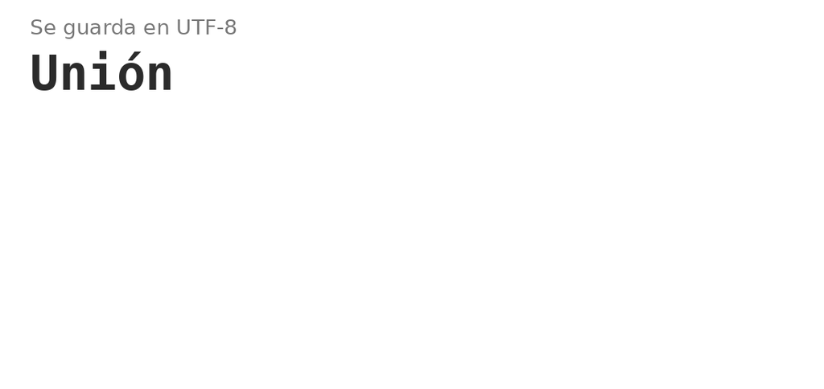

Al revés, un archivo en Latin-1 leído como UTF-8 sí da error 💥:

```
UnicodeDecodeError: 'utf-8' codec can't decode byte 0xf3 in position 59: invalid continuation byte
```

La solución es decirle a pandas la codificación: `pd.read_csv(ruta, encoding="latin-1")`.

## Regla para la codificación: primero UTF-8 🧭

[output not shown]

**Por qué primero UTF-8.** UTF-8 tiene un molde: si los bytes no encajan, da error y avisa. Latin-1 no avisa nunca, porque los 256 bytes posibles son letras válidas. Si se empieza por Latin-1, el texto puede quedar mal sin que nada lo indique.

**Para ver en qué está guardado:** el Bloc de notas y VS Code lo muestran abajo a la derecha (*UTF-8* o *ANSI*). **Para pasarlo a UTF-8:** Bloc de notas → *Guardar como* → Codificación *UTF-8*.

## Cuatro síntomas al leer un CSV, y su causa

[output not shown]

Los tres primeros se resuelven con argumentos de `pd.read_csv`, sin modificar el archivo. El cuarto no tiene que ver con el contenido: el programa no encontró el archivo.

```python
pd.read_csv("ventas_pc.csv", sep=";", decimal=",", encoding="utf-8")
```

## Actividad: escribir un CSV a mano y romperlo 🔨

1. Abrir el Bloc de notas y escribir una tabla de cinco filas: fecha, local y monto.
2. Guardarla como `mis_ventas.csv`, en la carpeta de la clase, con codificación UTF-8.
3. Leerla con pandas y comprobar que tiene 5 filas y 3 columnas.
4. Romperla de a una cosa por vez: separador, decimal, codificación, nombre. Anotar el síntoma que aparece.
5. Arreglar cada síntoma con un argumento de `pd.read_csv`, sin volver a tocar el archivo.

Los pasos están en `practico_archivos.py`.

# Carpetas y rutas

## El sistema de archivos es un árbol 🌳

```
C:/
└── Users/
    └── ana/
        └── curso/
            └── clases/
                ├── clase10/
                │   └── transito_aire_junio2024.csv
                └── clase12/
                    └── clase12_ejercicios.py
```

**Carpeta** (directorio). Un lugar con nombre que contiene archivos y otras carpetas. 📁

**Raíz.** La carpeta que contiene a todas las demás: `C:/` en Windows, `/` en Mac y Linux.

**Ruta.** La lista de carpetas que hay que recorrer para llegar a un archivo, separadas por `/`.

## Ruta absoluta y ruta relativa

**Ruta absoluta.** Empieza en la raíz. Solo sirve en la computadora donde existe esa carpeta. 🏠

```
C:/Users/ana/curso/clases/clase10/transito_aire_junio2024.csv
```

**Ruta relativa.** Empieza en el directorio de trabajo. Desde `curso/`: 🧭

```
clases/clase10/transito_aire_junio2024.csv
```

La ruta relativa funciona en la computadora de cualquier compañero que tenga la carpeta `curso/`, esté donde esté.

## El directorio de trabajo decide dónde se busca

**Directorio de trabajo.** La carpeta desde la que el programa resuelve las rutas relativas. En Python se ve con `Path.cwd()`; en R, con `getwd()`. Dos puntos (`..`) significan «subir una carpeta».

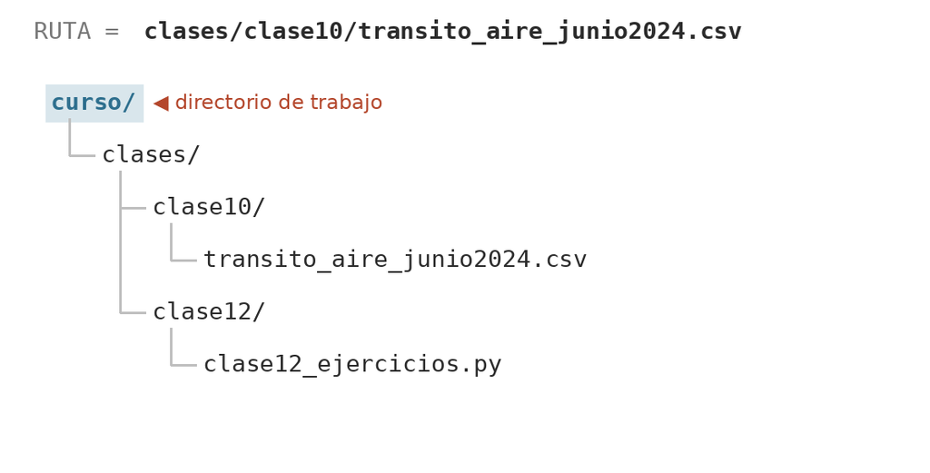

## En VS Code, cada forma de correr usa otra carpeta

**▶️ Run Python File**

Corre el script en la terminal. El directorio de trabajo es la carpeta abierta en VS Code (*Archivo → Abrir carpeta*).

```
curso/
```

**🧩 Por celdas `#%%`** (Shift + Enter)

Corre en la ventana interactiva. El directorio de trabajo es, por defecto, la carpeta donde está el script.

```
curso/clases/clase12/
```

**Regla del curso:** se abre siempre la carpeta del repositorio, nunca un archivo suelto. El repositorio trae el archivo `.vscode/settings.json`, que hace que las celdas también usen la carpeta del repositorio. Así las dos formas de correr dan el mismo directorio de trabajo.

## Dos líneas al comienzo de cada script ✅

```python
from pathlib import Path

RUTA = "clases/clase10/transito_aire_junio2024.csv"

print(Path.cwd())            # dónde está parado el programa
print(Path(RUTA).exists())   # True si el archivo está ahí
```

- **Si dice `True`** ✅, la ruta está bien y se puede leer el archivo.
- **Si dice `False`** ❌, el problema es la ruta. Se compara lo que imprimió `Path.cwd()` con el árbol de carpetas, y se corrige la ruta o la carpeta abierta.

Con estas dos líneas, un `FileNotFoundError` deja de ser un mensaje largo y se vuelve una pregunta con respuesta: ¿desde dónde corre el programa, y dónde está el archivo?

## Fuentes

McKinney, W. (2022). *Python for Data Analysis* (3.ª ed.). O’Reilly. Cap. 6: Data Loading, Storage, and File Formats.

Wickham, H., Çetinkaya-Rundel, M. y Grolemund, G. (2023). *R for Data Science* (2.ª ed.). O’Reilly. Cap. 6: Workflow: scripts and projects.

Shafranovich, Y. (2005). *Common Format and MIME Type for Comma-Separated Values (CSV) Files*. RFC 4180, IETF.

Yergeau, F. (2003). *UTF-8, a transformation format of ISO 10646*. RFC 3629, IETF.

The Unicode Consortium (2024). *The Unicode Standard*, versión 16.0.

Pike, R. (2003). *UTF-8 history*. Correo electrónico reproducido en doc.cat-v.org/bell_labs/utf-8_history.

W3Techs (2026). *Usage statistics of character encodings for websites*.

Python Software Foundation. *pathlib — Object-oriented filesystem paths*. Documentación de Python 3.

pandas development team. *pandas.read_csv*. Documentación de pandas.